# The effect of a dominant shrub on annuals plants in a desert system changes along a gradient of precipitation.

Alex Filazzola

May 2017

### Ephedra regional gradient (ERG) analyses

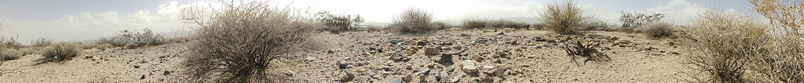

[ecoblender](http://ecoblender.org)

[alex.filazzola](http://www.filazzola.info)

### Abstract

An under-examined component of the shrub-annual relationship is how regional drivers, such as climate, may alter the sign or magnitude of positive interactions. Interspecific interactions between plants have been shown to be strongly linked to climate, particularly temperature and precipitation. The stress-gradient hypothesis (SGH) predicts that higher abiotic stress (i.e. for deserts, increasing temperature and reduced precipitation) will increase the frequency of positive interactions among shrubs and their annual understory. Regional climate gradients also have indirect effects on plant composition, such as determining consumer abundance and soil nutrient composition. Nutrient availability is particularly affected by precipitation because of altered decomposition rates of organic matter and mineralization. Therefore, the strength of facilitation and operating mechanism of a shrub on the annual plant community may change along a regional gradient.

### Hypothesis

We tested the hypothesis that positive interactions among shrubs and annual plants will increase with abiotic stress and reduce nutrient availability along a regional gradient of aridity.

### Methods

[figure not shown]

### Load libraries, data, and functions

```r
## load packages
library(tidyverse)
library(effects)
library(lme4)
library(lmerTest)

## Load functions

se <- function(x, ...) sd(x)/sqrt(length(x)) ## standard error

source("functions.r")
source("rsquared.r")

## inverse hyperbolic sine transformation for zero laden data that fits log transformations
##Zhang, M., Fortney, J. C., Tilford, J. M., & Rost, K. M. (2000). An application of the inverse hyperbolic sine transformation—a note. Health Services and Outcomes Research Methodology, 1(2), 165-171.
ihs <- function(x) {
  y <- log(x + sqrt(x ^ 2 + 1))
  return(y)
}


## Load Aridity gradient
source("continentality.r") ## arid
arid$Year <- as.factor(arid$Year)
## Inverse aridity so larger numbers are more arid, smaler as less arid
arid$aridity <- 11 - arid$aridity

## load data
nutrient <- read.csv("Data//ERG.soilnutrients.csv")
community <- read.csv("Data//ERG.communitydata.csv")
community[is.na(community)] <- 0
census <-  read.csv("Data//ERG.phytometer.census.csv")
HOBOdata <- read.csv("Data//ERG.logger.data.csv")
sitevars <- read.csv("Data//ERG.shrub.csv")
```

### Weather for growing season

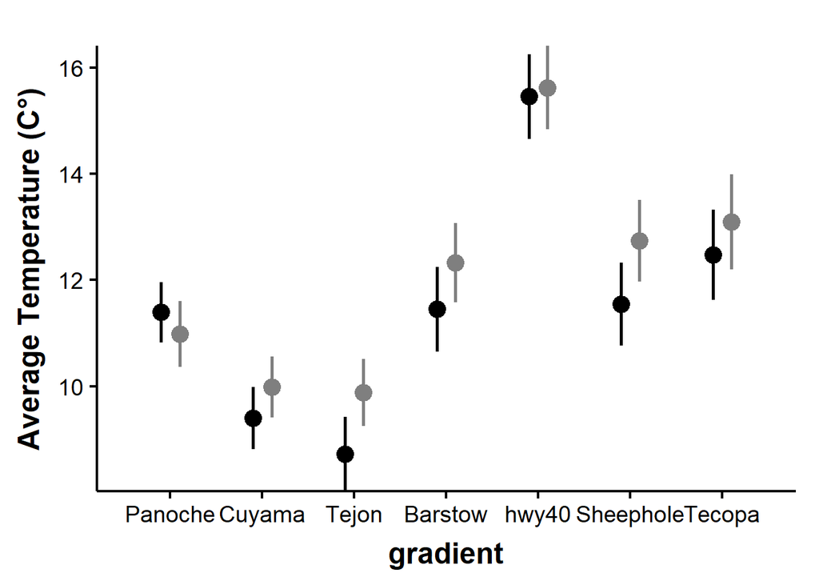

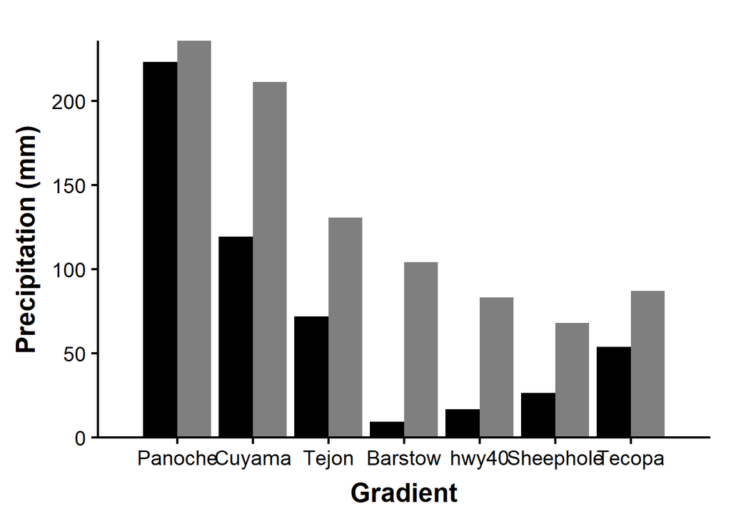

### Climate patterns within study

```r
season1.sjd <- season1 %>% filter(Gradient<4) %>% group_by(year, month,days) %>% summarise_if(is.numeric, funs(mean(., na.rm=T)))
```

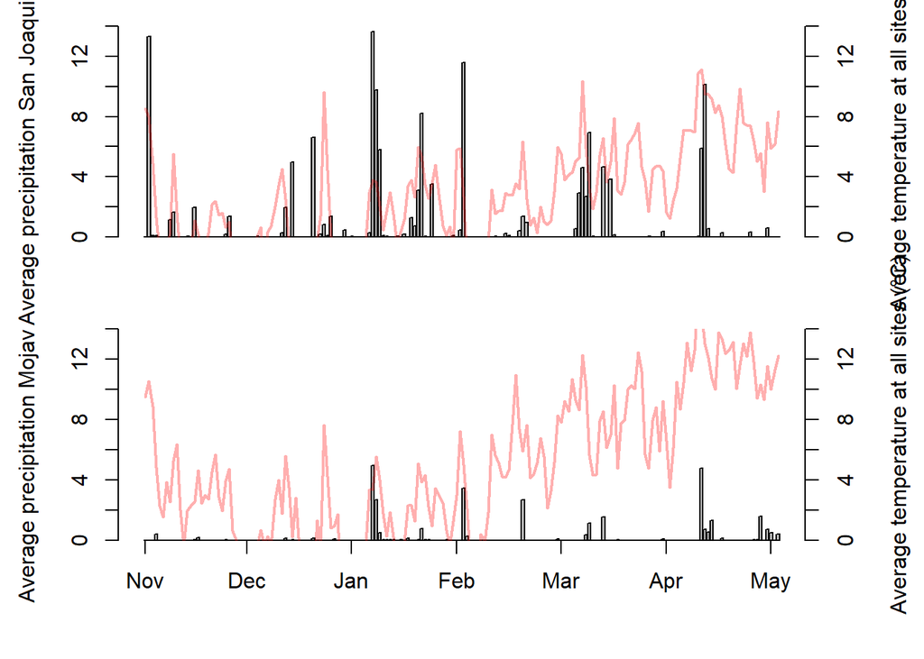

```r
season1.mnp <- season1 %>% filter(Gradient>3)%>% group_by(year, month,days) %>% summarise_if(is.numeric, funs(mean(., na.rm=T)))
season2.sjd <- season2 %>% filter(Gradient<4) %>% group_by(year, month,days) %>% summarise_if(is.numeric, funs(mean(., na.rm=T)))
season2.mnp <- season2 %>% filter(Gradient>3)%>% group_by(year, month,days) %>% summarise_if(is.numeric, funs(mean(., na.rm=T)))

## Rain vs Temperature in 2016
par(mfrow=c(2,1))
par(mar=c(3.5,4.5,1,4.5))
plot1 <- barplot(height=season1.sjd$Precip, ylim=c(0,14), ylab="Average precipitation San Joaquin (cm)")
points(plot1[,1], season1.sjd$min.temp, type="l", col="#FF000050", lwd=2)
axis(4, at=seq(0,14,2), lab=seq(0,14,2), ylab="")
mtext("Average temperature at all sites (°C)", 4, line=3)
par(mar=c(4.5,4.5,0,4.5))
plot1 <- barplot(height=season1.mnp$Precip, ylim=c(0,14), ylab="Average precipitation Mojave (cm)")
axis(1, plot1[c(1,30,60,90,120,150,180)], c("Nov","Dec","Jan","Feb","Mar","Apr","May"))
points(plot1[,1], season1.mnp$min.temp, type="l", col="#FF000050", lwd=2)
axis(4, at=seq(0,14,2), lab=seq(0,14,2), ylab="")
mtext("Average temperature at all sites (°C)", 4, line=3)
```

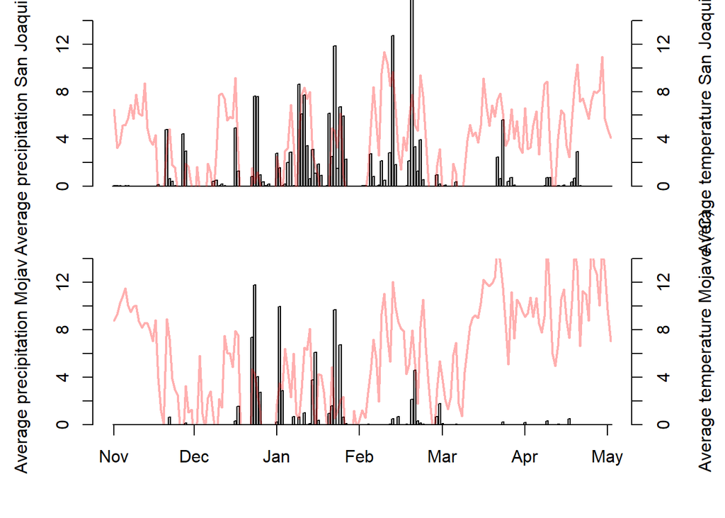

```r
## Rain vs Temperature in 2017
par(mfrow=c(2,1))
par(mar=c(3.5,4.5,1,4.5))
plot2 <- barplot(height=season2.sjd$Precip, ylim=c(0,14), ylab="Average precipitation San Joaquin (cm)")
points(plot2[,1], season2.sjd$min.temp, type="l", col="#FF000050", lwd=2)
axis(4, at=seq(0,14,2), lab=seq(0,14,2), ylab="")
mtext("Average temperature San Joaquin (°C)", 4, line=3)
par(mar=c(4.5,4.5,0,4.5))
plot2 <- barplot(height=season2.mnp$Precip, ylim=c(0,14), ylab="Average precipitation Mojave (cm)")
points(plot2[,1], season2.mnp$min.temp, type="l", col="#FF000050", lwd=2)
axis(1, plot1[c(1,30,60,90,120,150,180)], c("Nov","Dec","Jan","Feb","Mar","Apr","May"))
axis(4, at=seq(0,14,2), lab=seq(0,14,2), ylab="")
mtext("Average temperature Mojave (°C)", 4, line=3)
```

```r
### 2016 The rain was inconsistent and mostly absent in the Mojave. This resulted in low germination and producitivty at the southern sites
### 2017 The rain was more plentiful, but in the northern sites, there appears to be a frost period after the majority of the rainfall. Need to check number of frost days

season1.frost <- season1 %>% group_by(Site) %>% summarize(frost.days=sum(min.temp<0, na.rm=T)/length(min.temp)*100)
data.frame(season1.frost)
```

```
##              Site frost.days
## 1         Barstow  24.725275
## 2          Cuyama  29.670330
## 3   HeartofMojave  25.824176
## 4    PanocheHills  10.439560
## 5 SheepholeValley   6.043956
## 6          Tecopa  23.626374
## 7      TejonRanch  50.549451
```

```r
season2.frost <- season2 %>% group_by(Site) %>% summarize(frost.days=sum(min.temp<0, na.rm=T)/length(min.temp)*100)
data.frame(season2.frost)
```

```
##              Site frost.days
## 1         Barstow  17.679558
## 2          Cuyama  19.889503
## 3   HeartofMojave  16.574586
## 4    PanocheHills  14.917127
## 5 SheepholeValley   1.785714
## 6          Tecopa  25.966851
## 7      TejonRanch  35.911602
```

```r
## Both years had comparable number of frost days

## Compare number of consecutive frost days (i.e. frost periods)
season1[,"frost"] <- ifelse(season1$min.temp<0, -99,season1$min.temp) ## identified days below freezing
season2[,"frost"] <- ifelse(season2$min.temp<0, -99,season2$min.temp) ## identified days below freezing
count.consec <- function(x) {max(rle(as.character(x))$lengths)}

season1.frost <- season1 %>% group_by(Site)  %>% summarize(count.consec(frost))
data.frame(season1.frost)
```

```
##              Site count.consec.frost.
## 1         Barstow                  10
## 2          Cuyama                  10
## 3   HeartofMojave                  12
## 4    PanocheHills                   5
## 5 SheepholeValley                   7
## 6          Tecopa                  11
## 7      TejonRanch                  14
```

```r
season2.frost <- season2 %>% group_by(Site) %>% summarize(count.consec(frost))
data.frame(season2.frost)
```

```
##              Site count.consec.frost.
## 1         Barstow                   5
## 2          Cuyama                   6
## 3   HeartofMojave                   7
## 4    PanocheHills                   6
## 5 SheepholeValley                   3
## 6          Tecopa                   7
## 7      TejonRanch                  13
```

```r
## compare only after plants have germinated
season1.frost <- season1 %>% group_by(Site) %>% filter(year>2015) %>% summarize(frost.days=sum(min.temp<0, na.rm=T)/length(min.temp)*100, avg.min.temp=mean(min.temp, na.rm=T))
data.frame(season1.frost)
```

```
##              Site frost.days avg.min.temp
## 1         Barstow  12.396694     5.750413
## 2          Cuyama  11.570248     3.352893
## 3   HeartofMojave  16.528926     4.542149
## 4    PanocheHills   2.479339     6.777686
## 5 SheepholeValley   2.479339     9.394167
## 6          Tecopa  11.570248     6.342149
## 7      TejonRanch  33.884298     1.438017
```

```r
season2.frost <- season2 %>% group_by(Site) %>%  filter(year>2016) %>%  summarize(frost.days=sum(min.temp<0, na.rm=T)/length(min.temp)*100,avg.min.temp=mean(min.temp, na.rm=T))
data.frame(season2.frost)
```

```
##              Site frost.days avg.min.temp
## 1         Barstow  11.666667     6.052500
## 2          Cuyama  16.666667     3.624167
## 3   HeartofMojave   8.333333     5.637838
## 4    PanocheHills   8.333333     6.065833
## 5 SheepholeValley   0.000000     9.386916
## 6          Tecopa  20.833333     5.938333
## 7      TejonRanch  28.333333     2.535833
```

```r
season1.frost <- season1 %>% group_by(Site)  %>% filter(year>2015) %>% summarize(count.consec(frost))
data.frame(season1.frost)
```

```
##              Site count.consec.frost.
## 1         Barstow                   5
## 2          Cuyama                   6
## 3   HeartofMojave                   4
## 4    PanocheHills                   2
## 5 SheepholeValley                   2
## 6          Tecopa                   4
## 7      TejonRanch                  10
```

```r
season2.frost <- season2 %>% group_by(Site)  %>%  filter(year>2016)%>% summarize(count.consec(frost))
data.frame(season2.frost)
```

```
##              Site count.consec.frost.
## 1         Barstow                   5
## 2          Cuyama                   6
## 3   HeartofMojave                   3
## 4    PanocheHills                   3
## 5 SheepholeValley                   2
## 6          Tecopa                   5
## 7      TejonRanch                  10
```

### Ambient plant community response to aridity gradient and shrub facilitation

```r
## set colours for plots
obcol <- c("#E69F00","#56B4E9") ## Orange and blue
bgcol <- c("#000000","#707070") ## black and grey
scol <- obcol[1]
ocol <- obcol[2]



### Community First
commArid <- merge(community, arid, by=c("Site","Year"))
commArid[,"Year"] <- as.factor(commArid$Year)


## biomass model
m1 <- lmer(log(Biomass) ~ aridity * Microsite + Year + (1|ID), data=subset(commArid, Biomass>0))
anova(m1, test="Chisq")
```

```
## Type III Analysis of Variance Table with Satterthwaite's method
##                   Sum Sq Mean Sq NumDF  DenDF  F value    Pr(>F)
## aridity           333.16  333.16     1 216.22 497.4088 < 2.2e-16 ***
## Microsite          71.50   71.50     1 526.28 106.7552 < 2.2e-16 ***
## Year               98.68   98.68     1 681.55 147.3370 < 2.2e-16 ***
## aridity:Microsite   5.62    5.62     1 540.59   8.3933  0.003919 **
## ---
## Signif. codes:  0 '***' 0.001 '**' 0.01 '*' 0.05 '.' 0.1 ' ' 1
```

```r
shapiro.test(residuals(m1))
```

```
##
##  Shapiro-Wilk normality test
##
## data:  residuals(m1)
## W = 0.98756, p-value = 7.375e-06
```

```r
r.squared(m1)
```

```
##             Class   Family     Link  Marginal Conditional      AIC
## 1 lmerModLmerTest gaussian identity 0.5724485   0.6573578 1914.487
```

```r
## calcualte partial coefficents and confidence interval
ee <- Effect(c("aridity", "Microsite"), m1, xlevels=list(aridity=0:11))

## Extract polynomials
## Plot Biomass
plot1 <- ggplot(data=as.data.frame(ee), aes(x=aridity, y=fit, color=Microsite))+
  geom_jitter(data=subset(commArid, Biomass>0), aes(x=aridity, y=log(Biomass), color=Microsite), size=2, width = 0.2, alpha=1) + theme_Publication() + ylab("log-transformed biomass")+
   geom_line(lwd=2) +
  geom_ribbon(aes(ymin = lower, ymax=upper, fill=Microsite), alpha=0.3, color=NA) +
  scale_color_manual(values=c(scol, ocol)) + scale_fill_manual(values=c(scol, ocol)) +
  annotate("text", x=0,y=4, label="a", size=8) +
  guides(color=guide_legend(override.aes=list(fill=NA))) + xlim(0,10.5)


## species richness model
m2 <- glmer.nb(Richness ~ poly(aridity,2) * Microsite + Year + (1|ID), data=commArid)
car::Anova(m2, type=3)
```

```
## Analysis of Deviance Table (Type III Wald chisquare tests)
##
## Response: Richness
##                               Chisq Df Pr(>Chisq)
## (Intercept)                337.0107  1    < 2e-16 ***
## poly(aridity, 2)           378.6697  2    < 2e-16 ***
## Microsite                    4.3008  1    0.03809 *
## Year                         2.1686  1    0.14086
## poly(aridity, 2):Microsite 278.0963  2    < 2e-16 ***
## ---
## Signif. codes:  0 '***' 0.001 '**' 0.01 '*' 0.05 '.' 0.1 ' ' 1
```

```r
## calcualte partial coefficents and confidence interval
ee <- Effect(c("aridity", "Microsite"), m2, xlevels=list(aridity=0:11))


## Plot richness
plot2 <- ggplot(data=as.data.frame(ee), aes(x=aridity, y=fit, color=Microsite)) + theme_Publication() + ylab("species richness")+
   geom_jitter(data=subset(commArid, Biomass>0), aes(x=aridity, y=Richness, color=Microsite), size=2, width = 0.2, alpha=1) +
  geom_line(lwd=2) +
  geom_ribbon(aes(ymin = lower, ymax=upper, fill=Microsite), alpha=0.3, color=NA) +
  scale_color_manual(values=c(scol, ocol)) + scale_fill_manual(values=c(scol, ocol))+
  annotate("text", x=0,y=6, label="b", size=8) +
  guides(color=guide_legend(override.aes=list(fill=NA)))  + xlim(0,10.5)


## native vs non-native
status <- read.csv("Data//ERG.specieslist.csv")


statusComm <- community %>%  gather(Species.shorthand, abundance, 13:53)
statusLong <- merge(statusComm , status, by="Species.shorthand")
statusComm <- statusLong %>%   group_by(ID, Year, Site, Microsite, status, Rep) %>%  summarize(abd= sum(abundance)) %>%  data.frame(.) ## plants per plot

statusComm <- merge(statusComm, arid, by=c("Site","Year"))


## native only model
m4 <- glmer.nb( abd ~ poly(aridity,2) * Microsite  + Year + (1|ID), data=subset(statusComm, status=="native"), nAGQ=0)
car::Anova(m4, test="Chisq", type=3)
```

```
## Analysis of Deviance Table (Type III Wald chisquare tests)
##
## Response: abd
##                               Chisq Df Pr(>Chisq)
## (Intercept)                  6.4990  1    0.01079 *
## poly(aridity, 2)            71.3878  2  3.150e-16 ***
## Microsite                   51.8258  1  6.065e-13 ***
## Year                         6.5262  1    0.01063 *
## poly(aridity, 2):Microsite 174.0731  2  < 2.2e-16 ***
## ---
## Signif. codes:  0 '***' 0.001 '**' 0.01 '*' 0.05 '.' 0.1 ' ' 1
```

```r
MuMIn::r.squaredGLMM(m4)
```

```
##                 R2m       R2c
## delta     0.3226551 0.7416200
## lognormal 0.3503267 0.8052230
## trigamma  0.2768442 0.6363241
```

```r
## calcualte partial coefficents and confidence interval
ee <- Effect(c("aridity", "Microsite"), m4, xlevels=list(aridity=0:11)) %>% data.frame()

## abundance of natives
plot3 <- ggplot(data=data.frame(ee), aes(x=aridity, y=fit, color=Microsite)) + theme_Publication() + ylab("native plant abundance")+
  geom_jitter(data=subset(statusComm, status=="native" & abd>0), aes(x=aridity, y=abd, color=Microsite), size=2, width = 0.2, alpha=1) +
  geom_line(lwd=2) +
  geom_ribbon(aes(ymin = lower, ymax=upper, fill=Microsite), alpha=0.3, color=NA) +
  scale_color_manual(values=c(scol, ocol)) + scale_fill_manual(values=c(scol, ocol))+
scale_y_continuous(trans='log2', limits=c(0.2,140)) +annotate("text", x=0,y=65, label="c", size=8) +
  guides(color=guide_legend(override.aes=list(fill=NA)))  + xlim(0,10.5)

## non-native only model
m5 <- glmer.nb(abd ~ poly(aridity,2) * Microsite  + Year + (1|ID), data=subset(statusComm, status=="non.native"), nAGQ=0 )
car::Anova(m5, test="Chisq", type=2)
```

```
## Analysis of Deviance Table (Type II Wald chisquare tests)
##
## Response: abd
##                               Chisq Df Pr(>Chisq)
## poly(aridity, 2)           872.2272  2  < 2.2e-16 ***
## Microsite                   26.2480  1  3.003e-07 ***
## Year                        84.7387  1  < 2.2e-16 ***
## poly(aridity, 2):Microsite   7.7281  2    0.02098 *
## ---
## Signif. codes:  0 '***' 0.001 '**' 0.01 '*' 0.05 '.' 0.1 ' ' 1
```

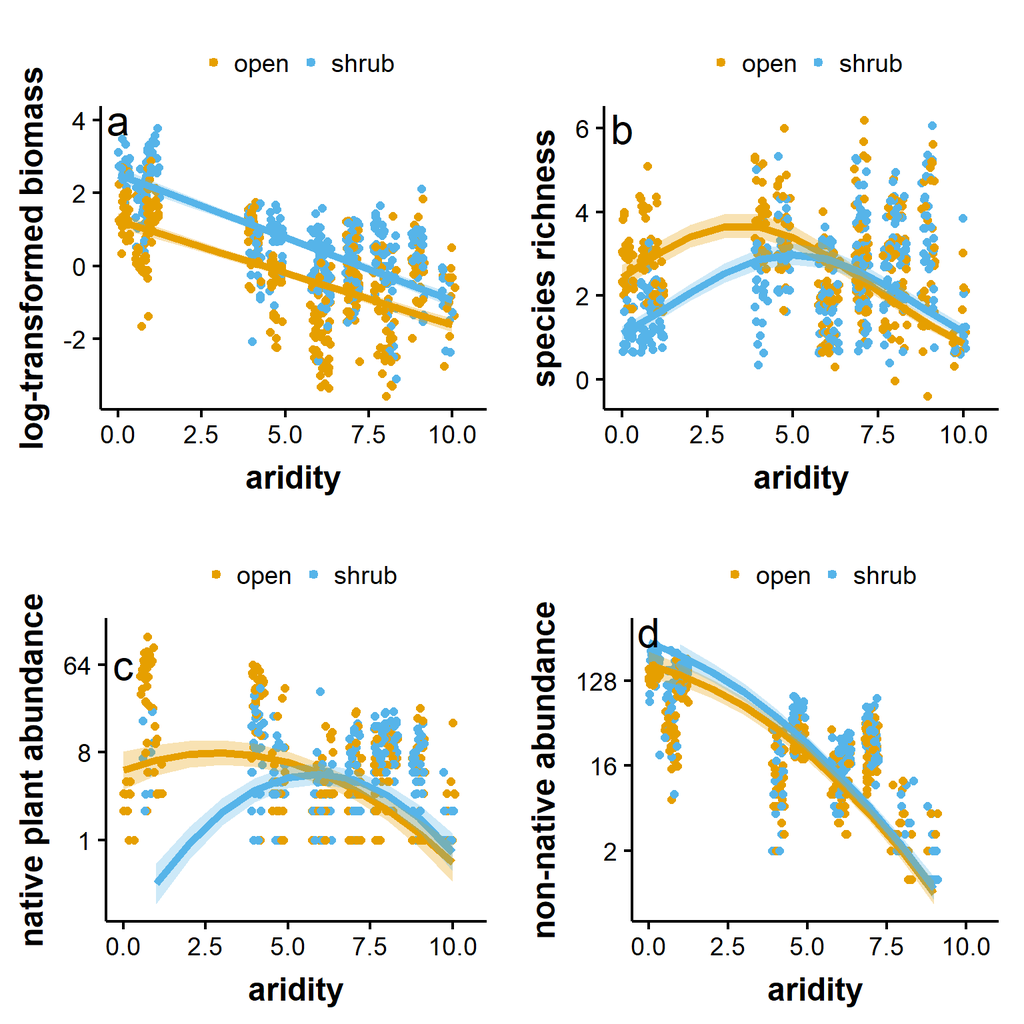

```r
## calcualte partial coefficents and confidence interval
ee <- Effect(c("aridity","Microsite"), m5, xlevels=list(aridity=0:11))


## abundance of non-natives
plot4 <- ggplot(data=as.data.frame(ee), aes(x=aridity, y=fit, color=Microsite)) + theme_Publication() + ylab("non-native abundance")+
  geom_jitter(data=subset(statusComm, status=="non.native" & abd>0), aes(x=aridity, y=abd, color=Microsite), size=2, width = 0.2, alpha=1) +
  geom_line(lwd=2) +
  geom_ribbon(aes(ymin = lower, ymax=upper, fill=Microsite), alpha=0.3, color=NA) +
  scale_color_manual(values=c(scol, ocol)) + scale_fill_manual(values=c(scol, ocol))+
  scale_y_continuous(trans='log2', limits=c(0.5,420)) +annotate("text", x=0,y=420, label="d", size=8) +
  guides(color=guide_legend(override.aes=list(fill=NA)))  + xlim(0,10.5)

require(gridExtra)
grid.arrange(plot1, plot2, plot3, plot4)
```

### Phytometer response to aridity gradient, nutrient addition, and shrub facilitation

```r
census <-  read.csv("Data//ERG.phytometer.census.csv")
end <- subset(census, Census=="end")

## Relevant nutrient to have ambient as control
end$Nutrient <- relevel(end$Nutrient, "Ambient")

phyto <- merge(end, arid, by=c("Year","Site"))
phyto$Year <- as.factor(phyto$Year)
phyto$Phacelia[is.na(phyto$Phacelia)] <- 0

## Run as Hurdle models

## create occurrence columns
phyto[,"pha.occ"] <- ifelse(phyto$Phacelia>0, 1,0)
phyto[,"pla.occ"] <- ifelse(phyto$Plantago>0, 1,0)
phyto[,"sal.occ"] <- ifelse(phyto$Salvia>0, 1,0)


## drop panoche 2017 because too cold
phyto <- phyto %>% filter(Site!="PanocheHills" | Year!="2017")

## Compare global models
occLong <- gather(phyto, species, occ, 23:25)
globalOcc <- glmer(occ ~ species:poly(aridity,2) + Microsite * species + species:Nutrient+ as.factor(Year) + (1|ID), data=occLong, family="binomial" , nAGQ=0)
car::Anova(globalOcc, test="Chisq")
```

```
## Analysis of Deviance Table (Type II Wald chisquare tests)
##
## Response: occ
##                             Chisq Df Pr(>Chisq)
## Microsite                  2.5333  1  0.1114636
## species                   98.5490  2  < 2.2e-16 ***
## as.factor(Year)           15.0918  1  0.0001024 ***
## species:poly(aridity, 2) 130.5057  6  < 2.2e-16 ***
## species:Microsite         29.0826  2  4.839e-07 ***
## species:Nutrient           1.2971  3  0.7298133
## ---
## Signif. codes:  0 '***' 0.001 '**' 0.01 '*' 0.05 '.' 0.1 ' ' 1
```

```r
bioLong <- gather(phyto, species, bio, 13:15)
globalBio <- lmer(log(bio) ~ species:poly(aridity,2) + Microsite * species + species:Nutrient + as.factor(Year) + (1|ID), data=bioLong)
anova(globalBio, test="Chisq")
```

```
## Type III Analysis of Variance Table with Satterthwaite's method
##                           Sum Sq Mean Sq NumDF  DenDF F value    Pr(>F)
## Microsite                  2.440   2.440     1 596.13  1.8376  0.175741
## species                   34.356  17.178     2 608.25 12.9366 3.147e-06 ***
## as.factor(Year)          131.155 131.155     1 692.88 98.7733 < 2.2e-16 ***
## species:poly(aridity, 2) 108.260  18.043     6 613.10 13.5885 1.639e-14 ***
## species:Microsite          8.509   4.255     2 580.30  3.2041  0.041314 *
## species:Nutrient          17.572   5.857     3 444.22  4.4112  0.004519 **
## ---
## Signif. codes:  0 '***' 0.001 '**' 0.01 '*' 0.05 '.' 0.1 ' ' 1
```

```r
## Phacelia occurrence
m1.occ <- glmer(pha.occ ~ poly(aridity,2) * Microsite * Nutrient + Year + (1|ID), data=phyto, family="binomial" , nAGQ=0)
glmer(pha.occ ~ poly(aridity,2, raw=T) * Microsite * Nutrient + Year + (1|ID), data=phyto, family="binomial" , nAGQ=0) ## produce co-efficients
```

```
## Generalized linear mixed model fit by maximum likelihood (Adaptive
##   Gauss-Hermite Quadrature, nAGQ = 0) [glmerMod]
##  Family: binomial  ( logit )
## Formula: pha.occ ~ poly(aridity, 2, raw = T) * Microsite * Nutrient +
##     Year + (1 | ID)
##    Data: phyto
##       AIC       BIC    logLik  deviance  df.resid
##  923.4394  988.6695 -447.7197  895.4394       766
## Random effects:
##  Groups Name        Std.Dev.
##  ID     (Intercept) 1.192
## Number of obs: 780, groups:  ID, 210
## Fixed Effects:
##                                             (Intercept)
##                                                -0.80082
##                              poly(aridity, 2, raw = T)1
##                                                 0.14694
##                              poly(aridity, 2, raw = T)2
##                                                -0.02443
##                                          Micrositeshrub
##                                                 1.79388
##                                           NutrientAdded
##                                                -0.94322
##                                                Year2017
##                                                -0.55462
##               poly(aridity, 2, raw = T)1:Micrositeshrub
##                                                -0.22836
##               poly(aridity, 2, raw = T)2:Micrositeshrub
##                                                 0.01199
##                poly(aridity, 2, raw = T)1:NutrientAdded
##                                                 0.53514
##                poly(aridity, 2, raw = T)2:NutrientAdded
##                                                -0.05144
##                            Micrositeshrub:NutrientAdded
##                                                -0.08353
## poly(aridity, 2, raw = T)1:Micrositeshrub:NutrientAdded
##                                                -0.22829
## poly(aridity, 2, raw = T)2:Micrositeshrub:NutrientAdded
##                                                 0.02844
```

```r
car::Anova(m1.occ, test="Chisq", type=2)
```

```
## Analysis of Deviance Table (Type II Wald chisquare tests)
##
## Response: pha.occ
##                                       Chisq Df Pr(>Chisq)
## poly(aridity, 2)                    20.6793  2  3.233e-05 ***
## Microsite                           24.2749  1  8.352e-07 ***
## Nutrient                             0.2708  1   0.602797
## Year                                 8.4866  1   0.003578 **
## poly(aridity, 2):Microsite           2.8242  2   0.243626
## poly(aridity, 2):Nutrient            2.5338  2   0.281697
## Microsite:Nutrient                   0.2762  1   0.599170
## poly(aridity, 2):Microsite:Nutrient  0.8215  2   0.663156
## ---
## Signif. codes:  0 '***' 0.001 '**' 0.01 '*' 0.05 '.' 0.1 ' ' 1
```

```r
## Phacelia Biomass
m1.bio <- lmer(log(Phacelia.biomass) ~ poly(aridity,2) * Microsite * Nutrient + as.factor(Year) + (1|ID), data=subset(phyto, pha.occ==1))
lmer(log(Phacelia.biomass) ~ poly(aridity,2, raw=T) * Microsite * Nutrient + as.factor(Year) + (1|ID), data=subset(phyto, pha.occ==1)) ## produce co-efficients
```

```
## Linear mixed model fit by REML ['lmerModLmerTest']
## Formula: log(Phacelia.biomass) ~ poly(aridity, 2, raw = T) * Microsite *
##     Nutrient + as.factor(Year) + (1 | ID)
##    Data: subset(phyto, pha.occ == 1)
## REML criterion at convergence: 779.7963
## Random effects:
##  Groups   Name        Std.Dev.
##  ID       (Intercept) 0.7009
##  Residual             1.2310
## Number of obs: 214, groups:  ID, 135
## Fixed Effects:
##                                             (Intercept)
##                                              -1.7827229
##                              poly(aridity, 2, raw = T)1
##                                               0.0410249
##                              poly(aridity, 2, raw = T)2
##                                              -0.0172080
##                                          Micrositeshrub
##                                               1.1401106
##                                           NutrientAdded
##                                               0.0555715
##                                     as.factor(Year)2017
##                                               0.9680020
##               poly(aridity, 2, raw = T)1:Micrositeshrub
##                                              -0.0972093
##               poly(aridity, 2, raw = T)2:Micrositeshrub
##                                              -0.0005373
##                poly(aridity, 2, raw = T)1:NutrientAdded
##                                               0.3016420
##                poly(aridity, 2, raw = T)2:NutrientAdded
##                                              -0.0310988
##                            Micrositeshrub:NutrientAdded
##                                               0.1922660
## poly(aridity, 2, raw = T)1:Micrositeshrub:NutrientAdded
##                                              -0.5069094
## poly(aridity, 2, raw = T)2:Micrositeshrub:NutrientAdded
##                                               0.0612628
```

```r
anova(m1.bio, test="Chisq")
```

```
## Type III Analysis of Variance Table with Satterthwaite's method
##                                     Sum Sq Mean Sq NumDF  DenDF F value
## poly(aridity, 2)                    30.584  15.292     2 185.92 10.0916
## Microsite                            9.673   9.673     1 155.32  6.3833
## Nutrient                             5.044   5.044     1 128.69  3.3289
## as.factor(Year)                     35.208  35.208     1 162.81 23.2347
## poly(aridity, 2):Microsite           2.321   1.161     2 157.69  0.7660
## poly(aridity, 2):Nutrient            0.520   0.260     2 176.85  0.1715
## Microsite:Nutrient                   0.122   0.122     1 154.04  0.0807
## poly(aridity, 2):Microsite:Nutrient  2.972   1.486     2 158.12  0.9805
##                                        Pr(>F)
## poly(aridity, 2)                    6.906e-05 ***
## Microsite                             0.01252 *
## Nutrient                              0.07039 .
## as.factor(Year)                     3.266e-06 ***
## poly(aridity, 2):Microsite            0.46661
## poly(aridity, 2):Nutrient             0.84255
## Microsite:Nutrient                    0.77669
## poly(aridity, 2):Microsite:Nutrient   0.37738
## ---
## Signif. codes:  0 '***' 0.001 '**' 0.01 '*' 0.05 '.' 0.1 ' ' 1
```

```r
## Plantago occurrence
m2.occ <- glmer(pla.occ ~ poly(aridity,2) * Microsite * Nutrient + Year + (1|ID), data=phyto, family="binomial", nAGQ=0)
glmer(pla.occ ~ poly(aridity,2, raw=T) * Microsite * Nutrient + Year + (1|ID), data=phyto, family="binomial", nAGQ=0) ## produce co-efficient
```

```
## Generalized linear mixed model fit by maximum likelihood (Adaptive
##   Gauss-Hermite Quadrature, nAGQ = 0) [glmerMod]
##  Family: binomial  ( logit )
## Formula: pla.occ ~ poly(aridity, 2, raw = T) * Microsite * Nutrient +
##     Year + (1 | ID)
##    Data: phyto
##       AIC       BIC    logLik  deviance  df.resid
##  792.6133  857.8255 -382.3067  764.6133       765
## Random effects:
##  Groups Name        Std.Dev.
##  ID     (Intercept) 0.8672
## Number of obs: 779, groups:  ID, 210
## Fixed Effects:
##                                             (Intercept)
##                                                -0.56441
##                              poly(aridity, 2, raw = T)1
##                                                -0.28307
##                              poly(aridity, 2, raw = T)2
##                                                 0.02314
##                                          Micrositeshrub
##                                                -3.62791
##                                           NutrientAdded
##                                                -0.82673
##                                                Year2017
##                                                -0.01892
##               poly(aridity, 2, raw = T)1:Micrositeshrub
##                                                 1.07604
##               poly(aridity, 2, raw = T)2:Micrositeshrub
##                                                -0.07123
##                poly(aridity, 2, raw = T)1:NutrientAdded
##                                                 0.64101
##                poly(aridity, 2, raw = T)2:NutrientAdded
##                                                -0.06021
##                            Micrositeshrub:NutrientAdded
##                                               -12.86898
## poly(aridity, 2, raw = T)1:Micrositeshrub:NutrientAdded
##                                                 3.16481
## poly(aridity, 2, raw = T)2:Micrositeshrub:NutrientAdded
##                                                -0.20027
```

```r
car::Anova(m2.occ, test="Chisq", type=3)
```

```
## Analysis of Deviance Table (Type III Wald chisquare tests)
##
## Response: pla.occ
##                                       Chisq Df Pr(>Chisq)
## (Intercept)                         32.0971  1  1.467e-08 ***
## poly(aridity, 2)                     1.5843  2   0.452876
## Microsite                            0.9069  1   0.340940
## Nutrient                             1.4245  1   0.232665
## Year                                 0.0083  1   0.927585
## poly(aridity, 2):Microsite           7.6005  2   0.022365 *
## poly(aridity, 2):Nutrient            4.4085  2   0.110333
## Microsite:Nutrient                   6.9106  1   0.008569 **
## poly(aridity, 2):Microsite:Nutrient  3.9588  2   0.138154
## ---
## Signif. codes:  0 '***' 0.001 '**' 0.01 '*' 0.05 '.' 0.1 ' ' 1
```

```r
## Plantago Biomass
m2.bio <- lmer(log(Plantago.biomass) ~ poly(aridity,2) * Microsite * Nutrient + as.factor(Year) + (1|ID), data=subset(phyto, pla.occ==1))
lmer(log(Plantago.biomass) ~ poly(aridity,2, raw=T) * Microsite * Nutrient + as.factor(Year) + (1|ID), data=subset(phyto, pla.occ==1)) ## produce co-efficient
```

```
## Linear mixed model fit by REML ['lmerModLmerTest']
## Formula: log(Plantago.biomass) ~ poly(aridity, 2, raw = T) * Microsite *
##     Nutrient + as.factor(Year) + (1 | ID)
##    Data: subset(phyto, pla.occ == 1)
## REML criterion at convergence: 412.2272
## Random effects:
##  Groups   Name        Std.Dev.
##  ID       (Intercept) 0.4899
##  Residual             0.9537
## Number of obs: 131, groups:  ID, 92
## Fixed Effects:
##                                             (Intercept)
##                                                -1.39024
##                              poly(aridity, 2, raw = T)1
##                                                -0.56821
##                              poly(aridity, 2, raw = T)2
##                                                 0.02616
##                                          Micrositeshrub
##                                                -0.07088
##                                           NutrientAdded
##                                                 0.12524
##                                     as.factor(Year)2017
##                                                 2.55458
##               poly(aridity, 2, raw = T)1:Micrositeshrub
##                                                -0.16182
##               poly(aridity, 2, raw = T)2:Micrositeshrub
##                                                 0.02239
##                poly(aridity, 2, raw = T)1:NutrientAdded
##                                                -0.15517
##                poly(aridity, 2, raw = T)2:NutrientAdded
##                                                 0.02833
##                            Micrositeshrub:NutrientAdded
##                                                -7.14305
## poly(aridity, 2, raw = T)1:Micrositeshrub:NutrientAdded
##                                                 2.06838
## poly(aridity, 2, raw = T)2:Micrositeshrub:NutrientAdded
##                                                -0.15018
```

```r
anova(m2.bio, test="Chisq")
```

```
## Type III Analysis of Variance Table with Satterthwaite's method
##                                      Sum Sq Mean Sq NumDF  DenDF  F value
## poly(aridity, 2)                      0.140   0.070     2 113.68   0.0770
## Microsite                             0.903   0.903     1 112.17   0.9928
## Nutrient                              0.012   0.012     1 117.58   0.0134
## as.factor(Year)                     109.035 109.035     1 117.58 119.8769
## poly(aridity, 2):Microsite            0.634   0.317     2 103.30   0.3486
## poly(aridity, 2):Nutrient             1.163   0.582     2 116.69   0.6394
## Microsite:Nutrient                    0.952   0.952     1 112.58   1.0471
## poly(aridity, 2):Microsite:Nutrient   1.755   0.878     2 103.15   0.9649
##                                     Pr(>F)
## poly(aridity, 2)                    0.9259
## Microsite                           0.3212
## Nutrient                            0.9081
## as.factor(Year)                     <2e-16 ***
## poly(aridity, 2):Microsite          0.7065
## poly(aridity, 2):Nutrient           0.5294
## Microsite:Nutrient                  0.3084
## poly(aridity, 2):Microsite:Nutrient 0.3844
## ---
## Signif. codes:  0 '***' 0.001 '**' 0.01 '*' 0.05 '.' 0.1 ' ' 1
```

```r
## calcualte partial coefficents and confidence interval
ee <- Effect(c("aridity","Microsite"), m2.occ, se=T, xlevels=data.frame(aridity=seq(0,11, by=0.2), Microsite = c(rep("shrub",56),rep("open",56)))) %>%  data.frame()

## Salvia occurrence
m3.occ <- glmer(sal.occ ~ poly(aridity,2) * Microsite * Nutrient + Year + (1|ID), data=phyto, family="binomial", nAGQ=0)
glmer(sal.occ ~ poly(aridity,2, raw=T) * Microsite * Nutrient + Year + (1|ID), data=phyto, family="binomial", nAGQ=0)
```

```
## Generalized linear mixed model fit by maximum likelihood (Adaptive
##   Gauss-Hermite Quadrature, nAGQ = 0) [glmerMod]
##  Family: binomial  ( logit )
## Formula: sal.occ ~ poly(aridity, 2, raw = T) * Microsite * Nutrient +
##     Year + (1 | ID)
##    Data: phyto
##       AIC       BIC    logLik  deviance  df.resid
## 1047.1696 1112.3817 -509.5848 1019.1696       765
## Random effects:
##  Groups Name        Std.Dev.
##  ID     (Intercept) 0.3558
## Number of obs: 779, groups:  ID, 210
## Fixed Effects:
##                                             (Intercept)
##                                               -0.259346
##                              poly(aridity, 2, raw = T)1
##                                                0.449431
##                              poly(aridity, 2, raw = T)2
##                                               -0.054111
##                                          Micrositeshrub
##                                               -0.127842
##                                           NutrientAdded
##                                               -0.361166
##                                                Year2017
##                                               -0.448877
##               poly(aridity, 2, raw = T)1:Micrositeshrub
##                                                0.146263
##               poly(aridity, 2, raw = T)2:Micrositeshrub
##                                               -0.010086
##                poly(aridity, 2, raw = T)1:NutrientAdded
##                                                0.177820
##                poly(aridity, 2, raw = T)2:NutrientAdded
##                                               -0.013361
##                            Micrositeshrub:NutrientAdded
##                                               -0.003606
## poly(aridity, 2, raw = T)1:Micrositeshrub:NutrientAdded
##                                               -0.266290
## poly(aridity, 2, raw = T)2:Micrositeshrub:NutrientAdded
##                                                0.022996
```

```r
car::Anova(m3.occ, test="Chisq", type=3)
```

```
## Analysis of Deviance Table (Type III Wald chisquare tests)
##
## Response: sal.occ
##                                       Chisq Df Pr(>Chisq)
## (Intercept)                          0.0193  1   0.889521
## poly(aridity, 2)                    13.3878  2   0.001238 **
## Microsite                            2.1402  1   0.143482
## Nutrient                             0.2897  1   0.590416
## Year                                 7.6415  1   0.005704 **
## poly(aridity, 2):Microsite           0.4538  2   0.796993
## poly(aridity, 2):Nutrient            0.5158  2   0.772662
## Microsite:Nutrient                   3.7155  1   0.053908 .
## poly(aridity, 2):Microsite:Nutrient  0.4687  2   0.791092
## ---
## Signif. codes:  0 '***' 0.001 '**' 0.01 '*' 0.05 '.' 0.1 ' ' 1
```

```r
## Salvia Biomass
m3.bio <- lmer(log(Salvia.biomass) ~ poly(aridity,2) * Microsite * Nutrient +  as.factor(Year) + (1|ID), data=subset(phyto, sal.occ==1))
lmer(log(Salvia.biomass) ~ poly(aridity,2, raw=T) * Microsite * Nutrient +  as.factor(Year) + (1|ID), data=subset(phyto, sal.occ==1))
```

```
## Linear mixed model fit by REML ['lmerModLmerTest']
## Formula: log(Salvia.biomass) ~ poly(aridity, 2, raw = T) * Microsite *
##     Nutrient + as.factor(Year) + (1 | ID)
##    Data: subset(phyto, sal.occ == 1)
## REML criterion at convergence: 1106.583
## Random effects:
##  Groups   Name        Std.Dev.
##  ID       (Intercept) 0.8122
##  Residual             1.0765
## Number of obs: 318, groups:  ID, 181
## Fixed Effects:
##                                             (Intercept)
##                                               -2.362177
##                              poly(aridity, 2, raw = T)1
##                                                0.417876
##                              poly(aridity, 2, raw = T)2
##                                               -0.059955
##                                          Micrositeshrub
##                                               -0.299705
##                                           NutrientAdded
##                                                0.306645
##                                     as.factor(Year)2017
##                                                1.039144
##               poly(aridity, 2, raw = T)1:Micrositeshrub
##                                                0.015854
##               poly(aridity, 2, raw = T)2:Micrositeshrub
##                                                0.007856
##                poly(aridity, 2, raw = T)1:NutrientAdded
##                                               -0.451572
##                poly(aridity, 2, raw = T)2:NutrientAdded
##                                                0.069380
##                            Micrositeshrub:NutrientAdded
##                                               -0.187874
## poly(aridity, 2, raw = T)1:Micrositeshrub:NutrientAdded
##                                                0.448441
## poly(aridity, 2, raw = T)2:Micrositeshrub:NutrientAdded
##                                               -0.062226
```

```r
anova(m3.bio, test="Chisq")
```

```
## Type III Analysis of Variance Table with Satterthwaite's method
##                                     Sum Sq Mean Sq NumDF  DenDF F value
## poly(aridity, 2)                    12.954   6.477     2 253.00  5.5891
## Microsite                            0.165   0.165     1 178.35  0.1420
## Nutrient                             8.690   8.690     1 152.79  7.4991
## as.factor(Year)                     52.781  52.781     1 295.70 45.5470
## poly(aridity, 2):Microsite           1.492   0.746     2 198.88  0.6438
## poly(aridity, 2):Nutrient            8.905   4.453     2 239.21  3.8424
## Microsite:Nutrient                   0.412   0.412     1 178.29  0.3559
## poly(aridity, 2):Microsite:Nutrient  5.127   2.563     2 198.97  2.2121
##                                        Pr(>F)
## poly(aridity, 2)                     0.004215 **
## Microsite                            0.706758
## Nutrient                             0.006907 **
## as.factor(Year)                     7.863e-11 ***
## poly(aridity, 2):Microsite           0.526388
## poly(aridity, 2):Nutrient            0.022777 *
## Microsite:Nutrient                   0.551565
## poly(aridity, 2):Microsite:Nutrient  0.112156
## ---
## Signif. codes:  0 '***' 0.001 '**' 0.01 '*' 0.05 '.' 0.1 ' ' 1
```

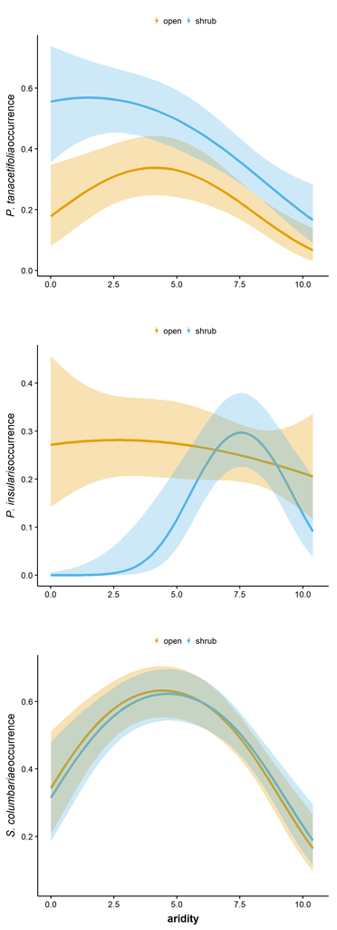

```r
## plot the phytometers

pha.ee <- Effect(c("aridity","Microsite"), m1.occ, se=T, xlevels=data.frame(aridity=seq(0,11, by=0.2), Microsite = c(rep("shrub",56),rep("open",56)))) %>%  data.frame()
pla.ee <- Effect(c("aridity","Microsite"), m2.occ, se=T, xlevels=data.frame(aridity=seq(0,11, by=0.2), Microsite = c(rep("shrub",56),rep("open",56)))) %>%  data.frame()
sal.ee <- Effect(c("aridity","Microsite"), m3.occ, se=T, xlevels=data.frame(aridity=seq(0,11, by=0.2), Microsite = c(rep("shrub",56),rep("open",56)))) %>%  data.frame()

## phytometer occurrence
plot1 <- ggplot(data=as.data.frame(pha.ee), aes(x=aridity, y=fit, color=Microsite)) + theme_Publication() +
  ylab(expression(italic("P. tanacetifolia")*"occurrence"))+ xlab("") +
   geom_line(lwd=2) +   geom_ribbon(aes(ymin = lower, ymax=upper, fill=Microsite), alpha=0.3, color=NA) +
  scale_color_manual(values=c("#E69F00", "#56B4E9")) + scale_fill_manual(values=c("#E69F00", "#56B4E9"))+ xlim(0,10.5)

plot2 <- ggplot(data=as.data.frame(pla.ee), aes(x=aridity, y=fit, color=Microsite)) + theme_Publication() +
  ylab(expression(italic("P. insularis")*"occurrence"))+ xlab("") +
  geom_line(lwd=2) +   geom_ribbon(aes(ymin = lower, ymax=upper, fill=Microsite), alpha=0.3, color=NA) +
  scale_color_manual(values=c("#E69F00", "#56B4E9")) + scale_fill_manual(values=c("#E69F00", "#56B4E9"))+ xlim(0,10.5)

plot3 <- ggplot(data=as.data.frame(sal.ee), aes(x=aridity, y=fit, color=Microsite)) + theme_Publication() +
  ylab(expression(italic("S. columbariae")*"occurrence"))+
  geom_line(lwd=2) +   geom_ribbon(aes(ymin = lower, ymax=upper, fill=Microsite), alpha=0.3, color=NA) +
  scale_color_manual(values=c("#E69F00", "#56B4E9")) + scale_fill_manual(values=c("#E69F00", "#56B4E9"))+ xlim(0,10.5)

gridExtra::grid.arrange(plot1, plot2, plot3, nrow=3)
```

### Analyze nutrients along aridity gradient in shrub canopies

```r
### abiotic characteristics
nutrient <- read.csv("Data//ERG.soilnutrients.csv")

nutArid <- merge(nutrient, subset(arid, Year==2017), by=c("Site"))

nutMean <- nutArid %>% group_by(aridity, microsite) %>%  summarize(n=mean(N),p=mean(P),k=mean(K), n.se=se(N), p.se=se(P), k.se=se(K))

m1 <- lm(log(N) ~ microsite * aridity, data=nutArid)
anova(m1)
```

```
## Analysis of Variance Table
##
## Response: log(N)
##                   Df Sum Sq Mean Sq F value    Pr(>F)
## microsite          1 40.160  40.160 28.3397 1.312e-06 ***
## aridity            1 18.617  18.617 13.1376 0.0005637 ***
## microsite:aridity  1  0.290   0.290  0.2045 0.6526263
## Residuals         66 93.528   1.417
## ---
## Signif. codes:  0 '***' 0.001 '**' 0.01 '*' 0.05 '.' 0.1 ' ' 1
```

```r
shapiro.test(m1$residuals)
```

```
##
##  Shapiro-Wilk normality test
##
## data:  m1$residuals
## W = 0.98748, p-value = 0.7143
```

```r
r.squared(m1)
```

```
##   Class   Family     Link  Marginal Conditional      AIC
## 1    lm gaussian identity 0.3870823          NA 228.9347
```

```r
m2 <- lm(log(P) ~ microsite * poly(aridity,2), data=nutArid)
anova(m2)
```

```
## Analysis of Variance Table
##
## Response: log(P)
##                            Df  Sum Sq Mean Sq F value    Pr(>F)
## microsite                   1 10.5455 10.5455  26.802 2.434e-06 ***
## poly(aridity, 2)            2 13.6050  6.8025  17.289 9.929e-07 ***
## microsite:poly(aridity, 2)  2  2.8558  1.4279   3.629   0.03214 *
## Residuals                  64 25.1819  0.3935
## ---
## Signif. codes:  0 '***' 0.001 '**' 0.01 '*' 0.05 '.' 0.1 ' ' 1
```

```r
shapiro.test(m2$residuals)
```

```
##
##  Shapiro-Wilk normality test
##
## data:  m2$residuals
## W = 0.93387, p-value = 0.001134
```

```r
r.squared(m2)
```

```
##   Class   Family     Link  Marginal Conditional      AIC
## 1    lm gaussian identity 0.5174789          NA 141.0856
```

```r
m3 <- lm(log(K) ~ microsite * aridity, data=nutArid)
anova(m3)
```

```
## Analysis of Variance Table
##
## Response: log(K)
##                   Df  Sum Sq Mean Sq F value    Pr(>F)
## microsite          1  4.4454  4.4454 22.7483 1.059e-05 ***
## aridity            1 11.3446 11.3446 58.0533 1.271e-10 ***
## microsite:aridity  1  0.0001  0.0001  0.0004    0.9833
## Residuals         66 12.8976  0.1954
## ---
## Signif. codes:  0 '***' 0.001 '**' 0.01 '*' 0.05 '.' 0.1 ' ' 1
```

```r
shapiro.test(m3$residuals)
```

```
##
##  Shapiro-Wilk normality test
##
## data:  m3$residuals
## W = 0.96769, p-value = 0.06742
```

```r
r.squared(m3)
```

```
##   Class   Family     Link  Marginal Conditional      AIC
## 1    lm gaussian identity 0.5504149          NA 90.24938
```

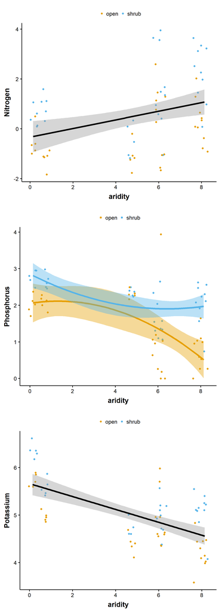

```r
plot1 <- ggplot(data=nutArid, aes(x=aridity, y= log(N))) + theme_Publication() +
  ylab("Nitrogen")+
  geom_jitter(size=2, width = 0.2, alpha=1, aes(color=microsite)) +
  geom_smooth(method="lm", lwd=2, lty=1, color="black") +
  scale_color_manual(values=c(scol, ocol)) +
  guides(color=guide_legend(override.aes=list(fill=NA)))

plot2 <- ggplot(data=nutArid, aes(x=aridity, y= log(P), color=microsite, fill=microsite)) + theme_Publication() +
  ylab("Phosphorus")+
  geom_jitter(size=2, width = 0.2, alpha=1) +
  geom_smooth(method="lm", lwd=2, formula = y ~ poly(x,2)) +
  scale_color_manual(values=c(scol, ocol)) +
  scale_fill_manual(values=c(scol, ocol)) +
  guides(color=guide_legend(override.aes=list(fill=NA)))

plot3 <- ggplot(data=nutArid, aes(x=aridity, y= log(K))) + theme_Publication() +
  ylab("Potassium")+
  geom_jitter(size=2, width = 0.2, alpha=1, aes(color=microsite)) +
  geom_smooth(method="lm", lwd=2, lty=1, color="black") +
  scale_color_manual(values=c(scol, ocol)) +
  guides(color=guide_legend(override.aes=list(fill=NA)))

require(gridExtra)
grid.arrange(plot1, plot2, plot3, nrow=3)
```